# Risk Factor Analysis

## Outcome Variable

**Outcome Variable:** pers_wast

## Predictor Variables

**Intervention Variable:** earlybf

**Adjustment Set:**

unadjusted

## Stratifying Variables

The analysis was stratified on these variable(s):

- agecat
- studyid
- country

## Data Summary

| agecat | studyid | country | earlybf | pers_wast | n_cell | n |
| --- | --- | --- | --- | --- | --- | --- |
| 0-24 months | EE | PAKISTAN | 1 | 0 | 63 | 366 |
| 0-24 months | EE | PAKISTAN | 1 | 1 | 6 | 366 |
| 0-24 months | EE | PAKISTAN | 0 | 0 | 271 | 366 |
| 0-24 months | EE | PAKISTAN | 0 | 1 | 26 | 366 |
| 0-24 months | GMS-Nepal | NEPAL | 1 | 0 | 143 | 543 |
| 0-24 months | GMS-Nepal | NEPAL | 1 | 1 | 18 | 543 |
| 0-24 months | GMS-Nepal | NEPAL | 0 | 0 | 327 | 543 |
| 0-24 months | GMS-Nepal | NEPAL | 0 | 1 | 55 | 543 |
| 0-24 months | MAL-ED | BANGLADESH | 1 | 0 | 144 | 247 |
| 0-24 months | MAL-ED | BANGLADESH | 1 | 1 | 8 | 247 |
| 0-24 months | MAL-ED | BANGLADESH | 0 | 0 | 90 | 247 |
| 0-24 months | MAL-ED | BANGLADESH | 0 | 1 | 5 | 247 |
| 0-24 months | MAL-ED | BRAZIL | 1 | 0 | 99 | 218 |
| 0-24 months | MAL-ED | BRAZIL | 1 | 1 | 1 | 218 |
| 0-24 months | MAL-ED | BRAZIL | 0 | 0 | 117 | 218 |
| 0-24 months | MAL-ED | BRAZIL | 0 | 1 | 1 | 218 |
| 0-24 months | MAL-ED | INDIA | 1 | 0 | 127 | 241 |
| 0-24 months | MAL-ED | INDIA | 1 | 1 | 16 | 241 |
| 0-24 months | MAL-ED | INDIA | 0 | 0 | 93 | 241 |
| 0-24 months | MAL-ED | INDIA | 0 | 1 | 5 | 241 |
| 0-24 months | MAL-ED | NEPAL | 1 | 0 | 94 | 238 |
| 0-24 months | MAL-ED | NEPAL | 1 | 1 | 3 | 238 |
| 0-24 months | MAL-ED | NEPAL | 0 | 0 | 140 | 238 |
| 0-24 months | MAL-ED | NEPAL | 0 | 1 | 1 | 238 |
| 0-24 months | MAL-ED | PERU | 1 | 0 | 211 | 284 |
| 0-24 months | MAL-ED | PERU | 1 | 1 | 1 | 284 |
| 0-24 months | MAL-ED | PERU | 0 | 0 | 72 | 284 |
| 0-24 months | MAL-ED | PERU | 0 | 1 | 0 | 284 |
| 0-24 months | MAL-ED | SOUTH AFRICA | 1 | 0 | 166 | 270 |
| 0-24 months | MAL-ED | SOUTH AFRICA | 1 | 1 | 1 | 270 |

[output cut: 110 more lines]

The following strata were considered:

- agecat: 0-24 months, studyid: EE, country: PAKISTAN
- agecat: 0-24 months, studyid: GMS-Nepal, country: NEPAL
- agecat: 0-24 months, studyid: MAL-ED, country: BANGLADESH
- agecat: 0-24 months, studyid: MAL-ED, country: BRAZIL
- agecat: 0-24 months, studyid: MAL-ED, country: INDIA
- agecat: 0-24 months, studyid: MAL-ED, country: NEPAL
- agecat: 0-24 months, studyid: MAL-ED, country: PERU
- agecat: 0-24 months, studyid: MAL-ED, country: SOUTH AFRICA
- agecat: 0-24 months, studyid: MAL-ED, country: TANZANIA, UNITED REPUBLIC OF
- agecat: 0-24 months, studyid: NIH-Crypto, country: BANGLADESH
- agecat: 0-24 months, studyid: SAS-CompFeed, country: INDIA
- agecat: 0-24 months, studyid: ZVITAMBO, country: ZIMBABWE
- agecat: 0-6 months, studyid: EE, country: PAKISTAN
- agecat: 0-6 months, studyid: GMS-Nepal, country: NEPAL
- agecat: 0-6 months, studyid: MAL-ED, country: BANGLADESH
- agecat: 0-6 months, studyid: MAL-ED, country: BRAZIL
- agecat: 0-6 months, studyid: MAL-ED, country: INDIA
- agecat: 0-6 months, studyid: MAL-ED, country: NEPAL
- agecat: 0-6 months, studyid: MAL-ED, country: PERU
- agecat: 0-6 months, studyid: MAL-ED, country: SOUTH AFRICA
- agecat: 0-6 months, studyid: MAL-ED, country: TANZANIA, UNITED REPUBLIC OF
- agecat: 0-6 months, studyid: NIH-Crypto, country: BANGLADESH
- agecat: 0-6 months, studyid: ZVITAMBO, country: ZIMBABWE
- agecat: 6-24 months, studyid: EE, country: PAKISTAN
- agecat: 6-24 months, studyid: GMS-Nepal, country: NEPAL
- agecat: 6-24 months, studyid: MAL-ED, country: BANGLADESH
- agecat: 6-24 months, studyid: MAL-ED, country: BRAZIL
- agecat: 6-24 months, studyid: MAL-ED, country: INDIA
- agecat: 6-24 months, studyid: MAL-ED, country: NEPAL
- agecat: 6-24 months, studyid: MAL-ED, country: PERU
- agecat: 6-24 months, studyid: MAL-ED, country: SOUTH AFRICA
- agecat: 6-24 months, studyid: MAL-ED, country: TANZANIA, UNITED REPUBLIC OF
- agecat: 6-24 months, studyid: NIH-Crypto, country: BANGLADESH
- agecat: 6-24 months, studyid: SAS-CompFeed, country: INDIA
- agecat: 6-24 months, studyid: ZVITAMBO, country: ZIMBABWE

### Dropped Strata

Some strata were dropped due to rare outcomes:

- agecat: 0-24 months, studyid: MAL-ED, country: BRAZIL
- agecat: 0-24 months, studyid: MAL-ED, country: NEPAL
- agecat: 0-24 months, studyid: MAL-ED, country: PERU
- agecat: 0-24 months, studyid: MAL-ED, country: SOUTH AFRICA
- agecat: 0-24 months, studyid: MAL-ED, country: TANZANIA, UNITED REPUBLIC OF
- agecat: 0-24 months, studyid: NIH-Crypto, country: BANGLADESH
- agecat: 0-6 months, studyid: EE, country: PAKISTAN
- agecat: 0-6 months, studyid: MAL-ED, country: BANGLADESH
- agecat: 0-6 months, studyid: MAL-ED, country: BRAZIL
- agecat: 0-6 months, studyid: MAL-ED, country: NEPAL
- agecat: 0-6 months, studyid: MAL-ED, country: PERU
- agecat: 0-6 months, studyid: MAL-ED, country: SOUTH AFRICA
- agecat: 0-6 months, studyid: MAL-ED, country: TANZANIA, UNITED REPUBLIC OF
- agecat: 0-6 months, studyid: NIH-Crypto, country: BANGLADESH
- agecat: 6-24 months, studyid: MAL-ED, country: BRAZIL
- agecat: 6-24 months, studyid: MAL-ED, country: NEPAL
- agecat: 6-24 months, studyid: MAL-ED, country: PERU
- agecat: 6-24 months, studyid: MAL-ED, country: SOUTH AFRICA
- agecat: 6-24 months, studyid: MAL-ED, country: TANZANIA, UNITED REPUBLIC OF
- agecat: 6-24 months, studyid: NIH-Crypto, country: BANGLADESH

## Methods Detail

We’re interested in the causal parameters $E[Y_a]$ for all values of $a \in \mathcal{A}$. These parameters represent the mean outcome if, possibly contrary to fact, we intervened to set all units to have $A=a$. Under the randomization and positivity assumptions, these are identified by the statistical parameters $\psi_a=E_W[E_{Y|A,W}(Y|A=a,W)]$. In addition, we’re interested in the mean of $Y$, $E[Y]$ under no intervention (the observed mean). We will estimate these parameters by using SuperLearner to fit the relevant likelihood factors – $E_{Y|A,W}(Y|A=a,W)$ and $p(A=a|W)$, and then updating our likelihood fit using a joint TMLE.

For unadjusted analyses ($W=\{\}$), initial likelihoods were estimated using Lrnr_glm to estimate the simple $E(Y|A)$ and Lrnr_mean to estimate $p(A)$. For adjusted analyses, a small library containing Lrnr_glmnet, Lrnr_xgboost, and Lrnr_mean was used.

Having estimated these parameters, we will then use the delta method to estimate relative risks and attributable risks relative to a prespecified baseline level of $A$.

# Results Detail

## Results Plots

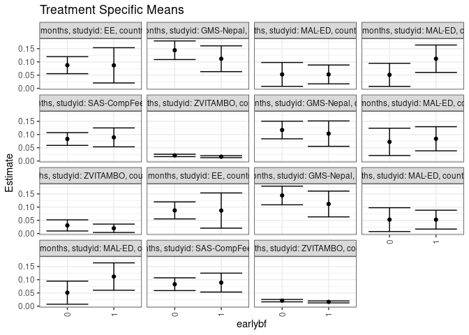

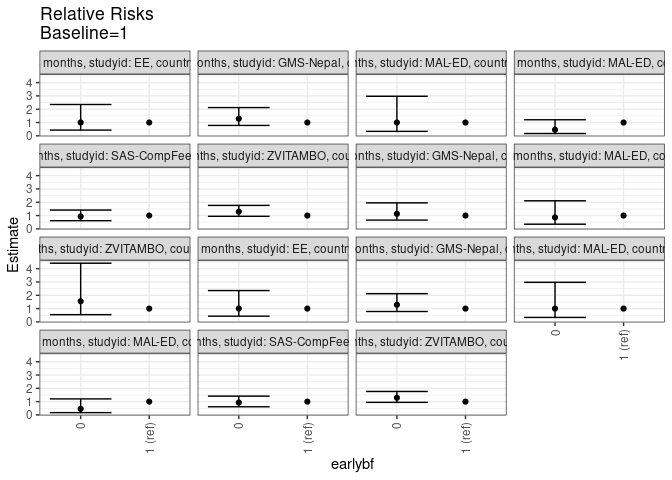

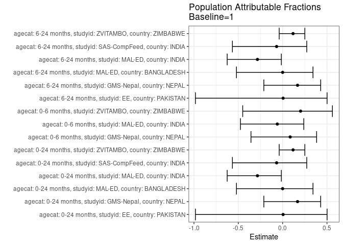

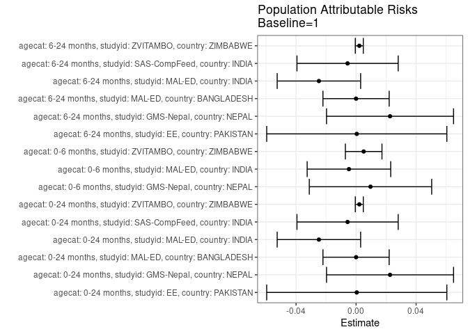

## Results Table

### Parameter: TSM

| agecat | studyid | country | intervention_level | baseline_level | estimate | ci_lower | ci_upper |
| --- | --- | --- | --- | --- | --- | --- | --- |
| 0-24 months | EE | PAKISTAN | 1 | NA | 0.0869565 | 0.0203810 | 0.1535320 |
| 0-24 months | EE | PAKISTAN | 0 | NA | 0.0875421 | 0.0553552 | 0.1197290 |
| 0-24 months | GMS-Nepal | NEPAL | 1 | NA | 0.1118012 | 0.0630805 | 0.1605220 |
| 0-24 months | GMS-Nepal | NEPAL | 0 | NA | 0.1439791 | 0.1087413 | 0.1792168 |
| 0-24 months | MAL-ED | BANGLADESH | 1 | NA | 0.0526316 | 0.0170611 | 0.0882021 |
| 0-24 months | MAL-ED | BANGLADESH | 0 | NA | 0.0526316 | 0.0076381 | 0.0976251 |
| 0-24 months | MAL-ED | INDIA | 1 | NA | 0.1118881 | 0.0601145 | 0.1636618 |
| 0-24 months | MAL-ED | INDIA | 0 | NA | 0.0510204 | 0.0073650 | 0.0946758 |
| 0-24 months | SAS-CompFeed | INDIA | 1 | NA | 0.0891089 | 0.0534033 | 0.1248146 |
| 0-24 months | SAS-CompFeed | INDIA | 0 | NA | 0.0830040 | 0.0588611 | 0.1071469 |
| 0-24 months | ZVITAMBO | ZIMBABWE | 1 | NA | 0.0161819 | 0.0125248 | 0.0198391 |
| 0-24 months | ZVITAMBO | ZIMBABWE | 0 | NA | 0.0208924 | 0.0163901 | 0.0253948 |
| 0-6 months | GMS-Nepal | NEPAL | 1 | NA | 0.1032258 | 0.0552811 | 0.1511705 |
| 0-6 months | GMS-Nepal | NEPAL | 0 | NA | 0.1169916 | 0.0837116 | 0.1502717 |
| 0-6 months | MAL-ED | INDIA | 1 | NA | 0.0839161 | 0.0383778 | 0.1294544 |
| 0-6 months | MAL-ED | INDIA | 0 | NA | 0.0721649 | 0.0205628 | 0.1237671 |
| 0-6 months | ZVITAMBO | ZIMBABWE | 1 | NA | 0.0199336 | 0.0041293 | 0.0357378 |
| 0-6 months | ZVITAMBO | ZIMBABWE | 0 | NA | 0.0308880 | 0.0097984 | 0.0519776 |
| 6-24 months | EE | PAKISTAN | 1 | NA | 0.0869565 | 0.0203810 | 0.1535320 |
| 6-24 months | EE | PAKISTAN | 0 | NA | 0.0875421 | 0.0553552 | 0.1197290 |
| 6-24 months | GMS-Nepal | NEPAL | 1 | NA | 0.1118012 | 0.0630805 | 0.1605220 |
| 6-24 months | GMS-Nepal | NEPAL | 0 | NA | 0.1439791 | 0.1087413 | 0.1792168 |
| 6-24 months | MAL-ED | BANGLADESH | 1 | NA | 0.0526316 | 0.0170611 | 0.0882021 |
| 6-24 months | MAL-ED | BANGLADESH | 0 | NA | 0.0526316 | 0.0076381 | 0.0976251 |
| 6-24 months | MAL-ED | INDIA | 1 | NA | 0.1118881 | 0.0601145 | 0.1636618 |
| 6-24 months | MAL-ED | INDIA | 0 | NA | 0.0510204 | 0.0073650 | 0.0946758 |
| 6-24 months | SAS-CompFeed | INDIA | 1 | NA | 0.0891089 | 0.0534033 | 0.1248146 |
| 6-24 months | SAS-CompFeed | INDIA | 0 | NA | 0.0830040 | 0.0588611 | 0.1071469 |
| 6-24 months | ZVITAMBO | ZIMBABWE | 1 | NA | 0.0161819 | 0.0125248 | 0.0198391 |
| 6-24 months | ZVITAMBO | ZIMBABWE | 0 | NA | 0.0208924 | 0.0163901 | 0.0253948 |

### Parameter: E(Y)

| agecat | studyid | country | intervention_level | baseline_level | estimate | ci_lower | ci_upper |
| --- | --- | --- | --- | --- | --- | --- | --- |
| 0-24 months | EE | PAKISTAN | NA | NA | 0.0874317 | 0.0584537 | 0.1164097 |
| 0-24 months | GMS-Nepal | NEPAL | NA | NA | 0.1344383 | 0.1057200 | 0.1631566 |
| 0-24 months | MAL-ED | BANGLADESH | NA | NA | 0.0526316 | 0.0247278 | 0.0805354 |
| 0-24 months | MAL-ED | INDIA | NA | NA | 0.0871369 | 0.0514552 | 0.1228187 |
| 0-24 months | SAS-CompFeed | INDIA | NA | NA | 0.0834553 | 0.0601989 | 0.1067118 |
| 0-24 months | ZVITAMBO | ZIMBABWE | NA | NA | 0.0183432 | 0.0154819 | 0.0212045 |
| 0-6 months | GMS-Nepal | NEPAL | NA | NA | 0.1128405 | 0.0854611 | 0.1402198 |
| 0-6 months | MAL-ED | INDIA | NA | NA | 0.0791667 | 0.0449364 | 0.1133970 |
| 0-6 months | ZVITAMBO | ZIMBABWE | NA | NA | 0.0250000 | 0.0120576 | 0.0379424 |
| 6-24 months | EE | PAKISTAN | NA | NA | 0.0874317 | 0.0584537 | 0.1164097 |
| 6-24 months | GMS-Nepal | NEPAL | NA | NA | 0.1344383 | 0.1057200 | 0.1631566 |
| 6-24 months | MAL-ED | BANGLADESH | NA | NA | 0.0526316 | 0.0247278 | 0.0805354 |
| 6-24 months | MAL-ED | INDIA | NA | NA | 0.0871369 | 0.0514552 | 0.1228187 |
| 6-24 months | SAS-CompFeed | INDIA | NA | NA | 0.0834553 | 0.0601989 | 0.1067118 |
| 6-24 months | ZVITAMBO | ZIMBABWE | NA | NA | 0.0183432 | 0.0154819 | 0.0212045 |

### Parameter: RR

| agecat | studyid | country | intervention_level | baseline_level | estimate | ci_lower | ci_upper |
| --- | --- | --- | --- | --- | --- | --- | --- |
| 0-24 months | EE | PAKISTAN | 1 | 1 | 1.0000000 | 1.0000000 | 1.000000 |
| 0-24 months | EE | PAKISTAN | 0 | 1 | 1.0067340 | 0.4305832 | 2.353815 |
| 0-24 months | GMS-Nepal | NEPAL | 1 | 1 | 1.0000000 | 1.0000000 | 1.000000 |
| 0-24 months | GMS-Nepal | NEPAL | 0 | 1 | 1.2878127 | 0.7812518 | 2.122826 |
| 0-24 months | MAL-ED | BANGLADESH | 1 | 1 | 1.0000000 | 1.0000000 | 1.000000 |
| 0-24 months | MAL-ED | BANGLADESH | 0 | 1 | 1.0000000 | 0.3362978 | 2.973555 |
| 0-24 months | MAL-ED | INDIA | 1 | 1 | 1.0000000 | 1.0000000 | 1.000000 |
| 0-24 months | MAL-ED | INDIA | 0 | 1 | 0.4559949 | 0.1723848 | 1.206205 |
| 0-24 months | SAS-CompFeed | INDIA | 1 | 1 | 1.0000000 | 1.0000000 | 1.000000 |
| 0-24 months | SAS-CompFeed | INDIA | 0 | 1 | 0.9314888 | 0.6140480 | 1.413035 |
| 0-24 months | ZVITAMBO | ZIMBABWE | 1 | 1 | 1.0000000 | 1.0000000 | 1.000000 |
| 0-24 months | ZVITAMBO | ZIMBABWE | 0 | 1 | 1.2910965 | 0.9447959 | 1.764328 |
| 0-6 months | GMS-Nepal | NEPAL | 1 | 1 | 1.0000000 | 1.0000000 | 1.000000 |
| 0-6 months | GMS-Nepal | NEPAL | 0 | 1 | 1.1333565 | 0.6573951 | 1.953919 |
| 0-6 months | MAL-ED | INDIA | 1 | 1 | 1.0000000 | 1.0000000 | 1.000000 |
| 0-6 months | MAL-ED | INDIA | 0 | 1 | 0.8599656 | 0.3504552 | 2.110230 |
| 0-6 months | ZVITAMBO | ZIMBABWE | 1 | 1 | 1.0000000 | 1.0000000 | 1.000000 |
| 0-6 months | ZVITAMBO | ZIMBABWE | 0 | 1 | 1.5495495 | 0.5442448 | 4.411808 |
| 6-24 months | EE | PAKISTAN | 1 | 1 | 1.0000000 | 1.0000000 | 1.000000 |
| 6-24 months | EE | PAKISTAN | 0 | 1 | 1.0067340 | 0.4305832 | 2.353815 |
| 6-24 months | GMS-Nepal | NEPAL | 1 | 1 | 1.0000000 | 1.0000000 | 1.000000 |
| 6-24 months | GMS-Nepal | NEPAL | 0 | 1 | 1.2878127 | 0.7812518 | 2.122826 |
| 6-24 months | MAL-ED | BANGLADESH | 1 | 1 | 1.0000000 | 1.0000000 | 1.000000 |
| 6-24 months | MAL-ED | BANGLADESH | 0 | 1 | 1.0000000 | 0.3362978 | 2.973555 |
| 6-24 months | MAL-ED | INDIA | 1 | 1 | 1.0000000 | 1.0000000 | 1.000000 |
| 6-24 months | MAL-ED | INDIA | 0 | 1 | 0.4559949 | 0.1723848 | 1.206205 |
| 6-24 months | SAS-CompFeed | INDIA | 1 | 1 | 1.0000000 | 1.0000000 | 1.000000 |
| 6-24 months | SAS-CompFeed | INDIA | 0 | 1 | 0.9314888 | 0.6140480 | 1.413035 |
| 6-24 months | ZVITAMBO | ZIMBABWE | 1 | 1 | 1.0000000 | 1.0000000 | 1.000000 |
| 6-24 months | ZVITAMBO | ZIMBABWE | 0 | 1 | 1.2910965 | 0.9447959 | 1.764328 |

### Parameter: PAR

| agecat | studyid | country | intervention_level | baseline_level | estimate | ci_lower | ci_upper |
| --- | --- | --- | --- | --- | --- | --- | --- |
| 0-24 months | EE | PAKISTAN | 1 | NA | 0.0004752 | -0.0595317 | 0.0604821 |
| 0-24 months | GMS-Nepal | NEPAL | 1 | NA | 0.0226371 | -0.0196812 | 0.0649553 |
| 0-24 months | MAL-ED | BANGLADESH | 1 | NA | 0.0000000 | -0.0220599 | 0.0220599 |
| 0-24 months | MAL-ED | INDIA | 1 | NA | -0.0247512 | -0.0525483 | 0.0030459 |
| 0-24 months | SAS-CompFeed | INDIA | 1 | NA | -0.0056536 | -0.0393651 | 0.0280580 |
| 0-24 months | ZVITAMBO | ZIMBABWE | 1 | NA | 0.0021613 | -0.0005006 | 0.0048231 |
| 0-6 months | GMS-Nepal | NEPAL | 1 | NA | 0.0096147 | -0.0311524 | 0.0503817 |
| 0-6 months | MAL-ED | INDIA | 1 | NA | -0.0047494 | -0.0325747 | 0.0230759 |
| 0-6 months | ZVITAMBO | ZIMBABWE | 1 | NA | 0.0050664 | -0.0071308 | 0.0172637 |
| 6-24 months | EE | PAKISTAN | 1 | NA | 0.0004752 | -0.0595317 | 0.0604821 |
| 6-24 months | GMS-Nepal | NEPAL | 1 | NA | 0.0226371 | -0.0196812 | 0.0649553 |
| 6-24 months | MAL-ED | BANGLADESH | 1 | NA | 0.0000000 | -0.0220599 | 0.0220599 |
| 6-24 months | MAL-ED | INDIA | 1 | NA | -0.0247512 | -0.0525483 | 0.0030459 |
| 6-24 months | SAS-CompFeed | INDIA | 1 | NA | -0.0056536 | -0.0393651 | 0.0280580 |
| 6-24 months | ZVITAMBO | ZIMBABWE | 1 | NA | 0.0021613 | -0.0005006 | 0.0048231 |

### Parameter: PAF

| agecat | studyid | country | intervention_level | baseline_level | estimate | ci_lower | ci_upper |
| --- | --- | --- | --- | --- | --- | --- | --- |
| 0-24 months | EE | PAKISTAN | 1 | NA | 0.0054348 | -0.9830339 | 0.5011886 |
| 0-24 months | GMS-Nepal | NEPAL | 1 | NA | 0.1683825 | -0.2120263 | 0.4293955 |
| 0-24 months | MAL-ED | BANGLADESH | 1 | NA | 0.0000000 | -0.5206498 | 0.3423864 |
| 0-24 months | MAL-ED | INDIA | 1 | NA | -0.2840493 | -0.6252463 | -0.0144817 |
| 0-24 months | SAS-CompFeed | INDIA | 1 | NA | -0.0677436 | -0.5664076 | 0.2721713 |
| 0-24 months | ZVITAMBO | ZIMBABWE | 1 | NA | 0.1178234 | -0.0385758 | 0.2506704 |
| 0-6 months | GMS-Nepal | NEPAL | 1 | NA | 0.0852058 | -0.3571379 | 0.3833725 |
| 0-6 months | MAL-ED | INDIA | 1 | NA | -0.0599926 | -0.4756633 | 0.2385903 |
| 0-6 months | ZVITAMBO | ZIMBABWE | 1 | NA | 0.2026578 | -0.4501982 | 0.5616085 |
| 6-24 months | EE | PAKISTAN | 1 | NA | 0.0054348 | -0.9830339 | 0.5011886 |
| 6-24 months | GMS-Nepal | NEPAL | 1 | NA | 0.1683825 | -0.2120263 | 0.4293955 |
| 6-24 months | MAL-ED | BANGLADESH | 1 | NA | 0.0000000 | -0.5206498 | 0.3423864 |
| 6-24 months | MAL-ED | INDIA | 1 | NA | -0.2840493 | -0.6252463 | -0.0144817 |
| 6-24 months | SAS-CompFeed | INDIA | 1 | NA | -0.0677436 | -0.5664076 | 0.2721713 |
| 6-24 months | ZVITAMBO | ZIMBABWE | 1 | NA | 0.1178234 | -0.0385758 | 0.2506704 |